# CharBase

Sebastian Valbuena

2025-08-13

# Pokedex

A continuacion vermichellean un trabajo sobre **La pokedex de Kanto** incluyendo algunas otras caracteristicas.

|  | ID | Nombre | Generacion | Region | Tipo 1 | Tipo 2 | Hp base | Ataque base | Defensa base | Ataque especial base | Defensa especial base | Velocidad base | Total base stats | Altura (M) | Peso (kg) | Tasa de captura | Es lengendario | Etapa evolutiva | Habilidad oculta | Proporcion de genero | Metodo de captura | Amistad base | Color | Forma |
| --- | --- | --- | --- | --- | --- | --- | --- | --- | --- | --- | --- | --- | --- | --- | --- | --- | --- | --- | --- | --- | --- | --- | --- | --- |
| 1 | 1 | Bulbasaur | 1 | Kanto | Grass | Poison | 45 | 49 | 49 | 65 | 65 | 45 | 318 | 0.7 | 6.9 | 45 | False | 1 | Chlorophyll | 87.5% male / 12.5% female | Wild/Starter | 70 | Green | Quadruped |
| 2 | 2 | Ivysaur | 1 | Kanto | Grass | Poison | 60 | 62 | 63 | 80 | 80 | 60 | 405 | 1 | 13 | 45 | False | 2 | Chlorophyll | 87.5% male / 12.5% female | Evolution | 70 | Green | Quadruped |
| 3 | 3 | Venusaur | 1 | Kanto | Grass | Poison | 80 | 82 | 83 | 100 | 100 | 80 | 525 | 2 | 100 | 45 | False | 3 | Chlorophyll | 87.5% male / 12.5% female | Evolution | 70 | Green | Quadruped |
| 4 | 4 | Charmander | 1 | Kanto | Fire |  | 39 | 52 | 43 | 60 | 50 | 65 | 309 | 0.6 | 8.5 | 45 | False | 1 | Solar Power | 87.5% male / 12.5% female | Wild/Starter | 70 | Red | Bipedal |
| 5 | 5 | Charmeleon | 1 | Kanto | Fire |  | 58 | 64 | 58 | 80 | 65 | 80 | 405 | 1.1 | 19 | 45 | False | 2 | Solar Power | 87.5% male / 12.5% female | Evolution | 70 | Red | Bipedal |
| 6 | 6 | Charizard | 1 | Kanto | Fire | Flying | 78 | 84 | 78 | 109 | 85 | 100 | 534 | 1.7 | 90.5 | 45 | False | 3 | Solar Power | 87.5% male / 12.5% female | Evolution | 70 | Red | Winged |
| 7 | 7 | Squirtle | 1 | Kanto | Water |  | 44 | 48 | 65 | 50 | 64 | 43 | 314 | 0.5 | 9 | 45 | False | 1 | Rain Dish | 87.5% male / 12.5% female | Wild/Starter | 70 | Blue | Bipedal |
| 8 | 8 | Wartortle | 1 | Kanto | Water |  | 59 | 63 | 80 | 65 | 80 | 58 | 405 | 1 | 22.5 | 45 | False | 2 | Rain Dish | 87.5% male / 12.5% female | Evolution | 70 | Blue | Bipedal |
| 9 | 9 | Blastoise | 1 | Kanto | Water |  | 79 | 83 | 100 | 85 | 105 | 78 | 530 | 1.6 | 85.5 | 45 | False | 3 | Rain Dish | 87.5% male / 12.5% female | Evolution | 70 | Blue | Bipedal |
| 10 | 10 | Caterpie | 1 | Kanto | Bug |  | 45 | 30 | 35 | 20 | 20 | 45 | 195 | 0.3 | 2.9 | 255 | False | 1 | Run Away | 50% male / 50% female | Wild | 70 | Green | Insectoid |

[output cut: 141 more lines]

# Informacion de los pokemones

## #001 **Bulbasaur**

### **Fotos**

[figure not shown]

foto de bulbasaur

### **Descripción de la Pokédex**

A este Pokémon le crece una semilla en el lomo desde que nace. La semilla acumula nutrientes para hacer crecer a la planta.

### **Origen**

**El nombre en ingles:** *Bulbasaur* proviene de la combinación de dos palabras en inglés: “bulb” *(bulbo)* y “saur” *(lagarto o saurio)*. Esto hace referencia a su apariencia física: un pequeño reptil con un bulbo de planta en la espalda.

**El nombre en japones:** *Fushigidane (フシギダネ)*, que se compone de “fushigi” *(不思議)*, que significa “misterio”, y “tane” *(種)*, que significa “semilla”. Juntos, su nombre se traduce como “semilla misteriosa”, haciendo alusión a la semilla que lleva en la espalda y al misterio de su crecimiento.

### **Caracteristicas**

Caracteristicas de Bulbasaur

| Tipo 1 | Tipo 2 | Proporcion de genero | Color | Forma | Altura (M) | Peso (kg) | Amistad base |
| --- | --- | --- | --- | --- | --- | --- | --- |
| Grass | Poison | 87.5% male / 12.5% female | Green | Quadruped | 0.7 | 6.9 | 70 |

### **Resistencias y Debilidades**

- **Débil:** Fuego, Hielo, Psíquico y Volador (recibe 2x de daño).
- **Resistente:** Agua, Eléctrico, Lucha y Planta (recibe 1/2 de daño).
- **Daño normal:** Normal, Veneno, Tierra, Roca, Bicho, Fantasma, Dragón y Acero (recibe 1x de daño).

### **Etapa evolutiva**

- *Bulbasaur* Evoluciona a *Ivysaur* en el nivel 16.
- *Ivysaur* evoluciona a *Venusaur* en el nivel 32.

### **Habilidades**

- **Normal:** Espesura (Overgrow)

**Efecto:** Aumenta la potencia de los movimientos de tipo Planta en un 50% cuando el PS del Pokémon está a 1/3 o menos de su capacidad máxima. Es una habilidad muy útil en situaciones de emergencia durante la batalla.

- **Oculta:** Clorofila (Chlorophyll)

**Efecto:** Duplica la Velocidad del Pokémon cuando el clima es Día Soleado o Sol Intenso. Es importante saber que esta habilidad no estaba disponible en los juegos originales “Pokémon Rojo Fuego” y “Verde Hoja”.

### **Metodo de captura**

En Pokémon Rojo Fuego, Bulbasaur es uno de los tres Pokémon iniciales que entrega el Profesor Oak en Pueblo Paleta, por lo que no se encuentra en estado salvaje.

### **Estadísticas**

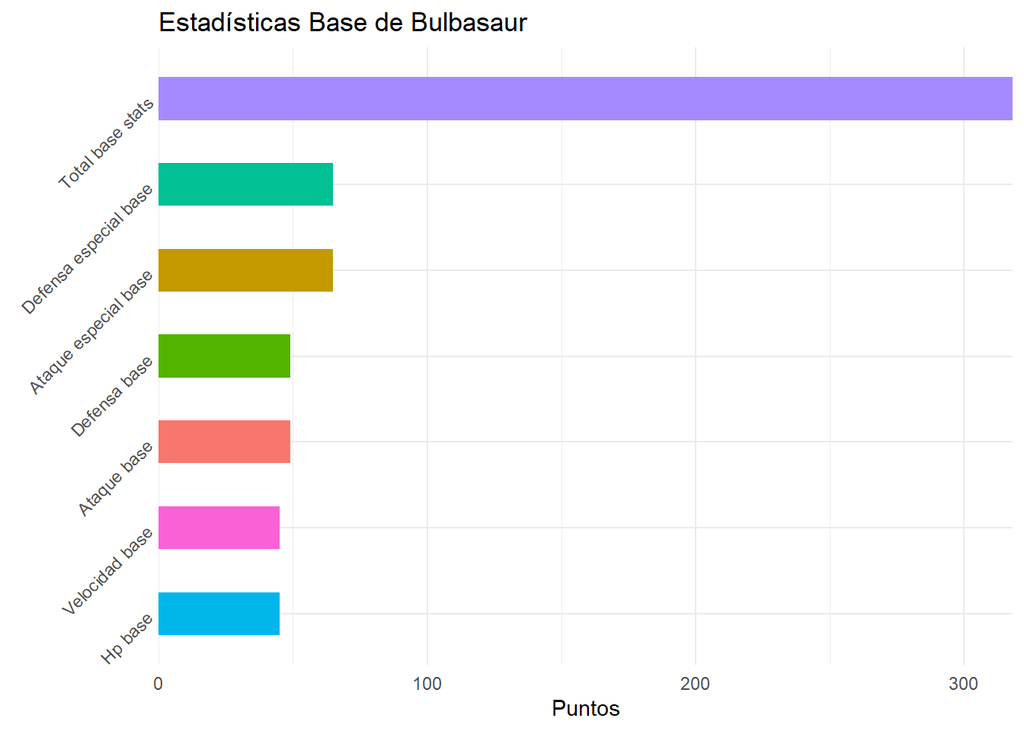

## #002 **Ivysaur**

### **Fotos**

[figure not shown]

Foto de Ivysaur

### **Descripción de la Pokédex**

Si el bulbo de su lomo empieza a oler dulce, es señal de que su floración está próxima.

### **Origen**

**Nombre en inglés:** *Ivysaur* combina las palabras “ivy” *(hiedra)* y “saur” *(lagarto)*. Esto se debe a las vides que brotan de su bulbo, que ahora está mucho más desarrollado que el de *Bulbasaur*.

**Nombre en japonés:** *Fushigisou (フシギソウ)* se traduce como “hierba misteriosa”, combinando “fushigi” *(misterio)* y “sou” *(hierba o planta)*.

### **Caracteristicas**

Caracteristicas de Ivysaur

| Tipo 1 | Tipo 2 | Proporcion de genero | Color | Forma | Altura (M) | Peso (kg) | Amistad base |
| --- | --- | --- | --- | --- | --- | --- | --- |
| Grass | Poison | 87.5% male / 12.5% female | Green | Quadruped | 1 | 13 | 70 |

### **Resistencias y Debilidades**

- **Débil:** Fuego, Hielo, Psíquico y Volador (recibe 2x de daño).
- **Resistente:** Agua, Eléctrico, Lucha y Planta (recibe 1/2 de daño).
- **Daño normal:** Normal, Veneno, Tierra, Roca, Bicho, Fantasma, Dragón y Acero (recibe 1x de daño).

### **Etapa evolutiva**

- *Ivysaur* evoluciona de *Bulbasaur* al alcanzar el nivel 16.
- *Ivysaur* evoluciona a *Venusaur* al alcanzar el nivel 32.

### **Habilidades**

- **Habilidad Normal:** Espesura (Overgrow)

**Efecto:** Aumenta la potencia de los movimientos de tipo Planta en un 50% cuando el PS del Pokémon está a 1/3 o menos de su capacidad máxima.

- **Habilidad Oculta:** Clorofila (Chlorophyll)

**Efecto:** Duplica la Velocidad del Pokémon cuando el clima es Día Soleado o Sol Intenso. Al igual que Bulbasaur, esta habilidad no está disponible en las versiones Pokémon Rojo Fuego y Verde Hoja.

### **Metodo de captura**

En Pokémon Rojo Fuego, Ivysaur no se encuentra en estado salvaje. La única forma de obtenerlo es evolucionando a Bulbasaur.

### **Estadísticas**

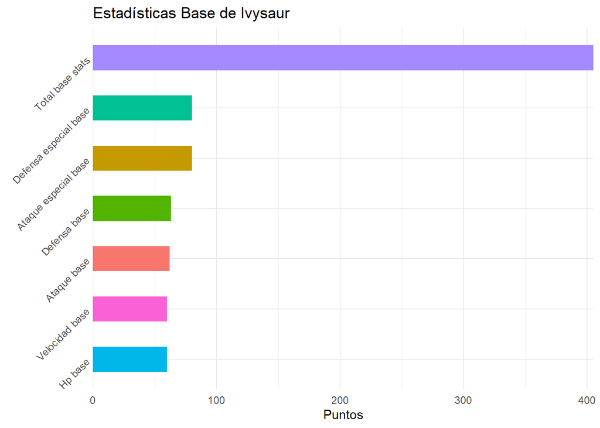

## #003 **Venusaur**

### **Fotos**

[figure not shown]

[figure not shown]

### **Descripcion de la pokedex**

La flor de su lomo adquiere colores vivos si recibe mucha luz solar. Su aroma tranquiliza los nervios.

### **Origen**

**Nombre en inglés:** *Venusaur* es una combinación de “Venus”, que hace referencia a la planta carnívora atrapamoscas *(Venus flytrap)*, y “saur”_ (lagarto o saurio)_. Esto alude a su apariencia de reptil con una flor gigante en la espalda que se asemeja a una planta carnívora.

**Nombre en japonés:** *Fushigibana* *(フシギバナ)*, que se traduce como “flor misteriosa”. Combina “fushigi” *(misterio)* y “hana” *(flor)*, haciendo referencia a la enorme flor que florece en su espalda.

### **Caracteristicas**

Caracteristicas de Venusaur

| Tipo 1 | Tipo 2 | Proporcion de genero | Color | Forma | Altura (M) | Peso (kg) | Amistad base |
| --- | --- | --- | --- | --- | --- | --- | --- |
| Grass | Poison | 87.5% male / 12.5% female | Green | Quadruped | 2 | 100 | 70 |

### **Resistencias y debilidades**

- **Débil:** Fuego, Hielo, Psíquico y Volador (recibe 2x de daño).
- **Resistente:** Agua, Eléctrico, Lucha y Planta (recibe 1/2 de daño).
- **Daño normal:** Normal, Veneno, Tierra, Roca, Bicho, Fantasma, Dragón y Acero (recibe 1x de daño).

### **Etapa evolutiva**

- *Venusaur* evoluciona de *Ivysaur* al alcanzar el nivel 32. Es la forma final de esta línea evolutiva.

### **Habilidades**

- **Habilidad Normal:** Espesura (Overgrow)

**Efecto:** Aumenta la potencia de los movimientos de tipo Planta en un 50% cuando el PS del Pokémon está a 1/3 o menos de su capacidad máxima.

- **Habilidad Oculta:** Clorofila (Chlorophyll)

**Efecto:** Duplica la Velocidad del Pokémon cuando el clima es Día Soleado o Sol Intenso. Al igual que sus preevoluciones, esta habilidad no está disponible en las versiones Pokémon Rojo Fuego y Verde Hoja.

### **Metodo de captura**

*Venusaur* no se encuentra en estado salvaje. La única forma de obtenerlo es evolucionando a *Ivysaur*.

### **Estadisticas**

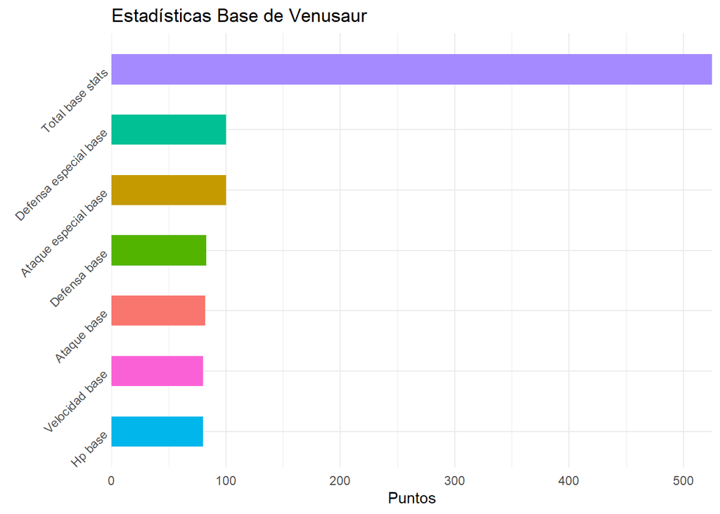

## #004 **Charmander**

### **Fotos**

[figure not shown]

Foto de Charmander

### **Descripcion de la pokedex**

Desde que nace, le arde una llama en la punta de la cola. Si la llama se apaga, el Pokémon muere.

### **Origen**

**Nombre en inglés:** *Charmander* es una combinación de “char” *(carbonizar, quemar)* y “mander” *(salamandra, del inglés “salamander”)*. Esto hace referencia a su naturaleza de tipo Fuego y a su apariencia de lagarto.

**Nombre en japonés:** *Hitokage (ヒトカゲ)* se traduce como “lagarto de fuego”. Proviene de “hi” *(火)*, que significa “fuego”, y “tokage” *(蜥蜴)*, que significa “lagarto”.

### **Caracteristicas**

Caracteristicas de Charmander

| Tipo 1 | Tipo 2 | Proporcion de genero | Color | Forma | Altura (M) | Peso (kg) | Amistad base |
| --- | --- | --- | --- | --- | --- | --- | --- |
| Fire | NA | 87.5% male / 12.5% female | Red | Bipedal | 0.6 | 8.5 | 70 |

### **Resistencias y debilidades**

- **Débil:** Agua, Tierra y Roca (recibe 2x de daño).
- **Resistente:** Bicho, Acero, Fuego, Hielo y Planta (recibe 1/2 de daño).
- **Daño normal:** Normal, Eléctrico, Lucha, Veneno, Psíquico, Volador, Fantasma y Dragón (recibe 1x de daño).

### **Etapa evolutiva**

- *Charmander* evoluciona a *Charmeleon* en el nivel 16.
- *Charmeleon* evoluciona a *Charizard* en el nivel 36.

### **Habilidades**

- **Habilidad Normal:** Mar Llamas (Blaze)

**Efecto:** Aumenta la potencia de los movimientos de tipo Fuego en un 50% cuando el PS del Pokémon está a 1/3 o menos de su capacidad máxima.

- **Habilidad Oculta:** Poder Solar (Solar Power)

**Efecto:** Aumenta el Ataque Especial del Pokémon en un 50% cuando el clima es Día Soleado o Sol Intenso, pero pierde un 1/8 de su PS máximo al final de cada turno. Esta habilidad no está disponible en Pokémon Rojo Fuego y Verde Hoja.

### **Metodo de captura**

Al igual que Bulbasaur, Charmander es uno de los tres Pokémon iniciales que el Profesor Oak ofrece en Pueblo Paleta, por lo que no se puede encontrar en estado salvaje en Pokémon Rojo Fuego.

### **Estadisticas**

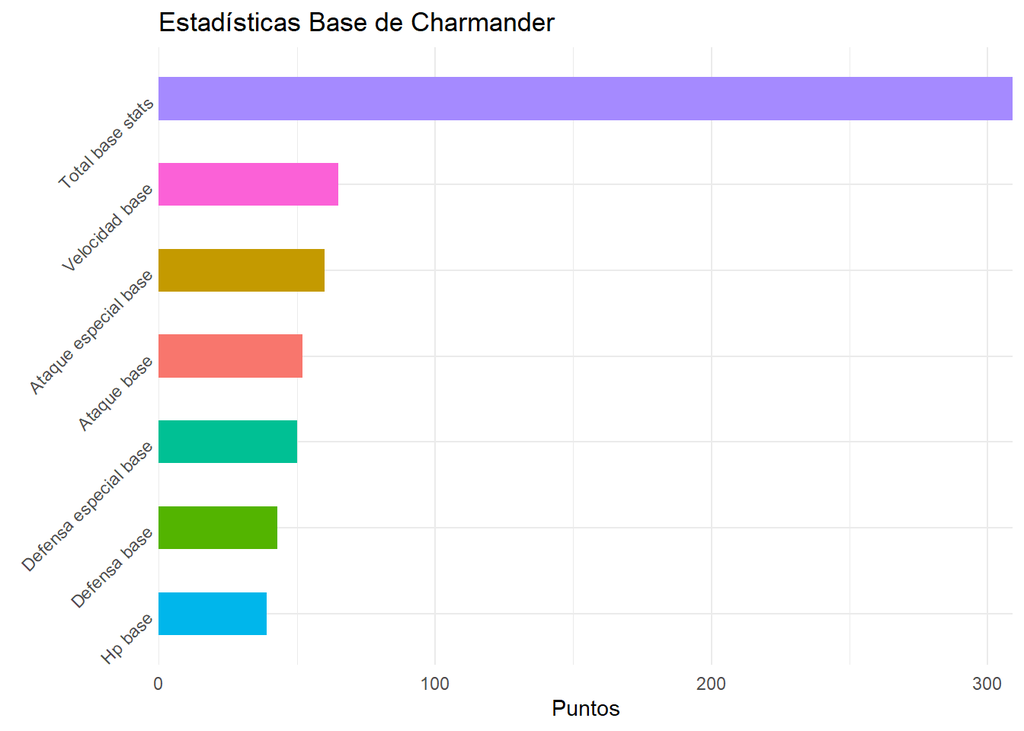

## #005 **Charmeleon**

### **Foto**

[figure not shown]

Foto de Charmeleon

### **Descripcion de la pokedex**

Este Pokémon destruye sin piedad a sus rivales con sus fuertes garras. Si se encuentra con un rival poderoso, la llama de su cola arde con gran intensidad.

### **Origen**

- **Nombre en inglés:** *Charmeleon* es una combinación de “char” *(carbonizar)* y “chameleon” *(camaleón)*, haciendo alusión a su naturaleza de tipo Fuego y su apariencia de reptil.
- **Nombre en japonés:** *Rizādo (リザード)* es una transcripción fonética de la palabra inglesa “lizard” *(lagarto)*.

### **Caracteristicas**

Caracteristicas de Charmeleon

| Tipo 1 | Tipo 2 | Proporcion de genero | Color | Forma | Altura (M) | Peso (kg) | Amistad base |
| --- | --- | --- | --- | --- | --- | --- | --- |
| Fire | NA | 87.5% male / 12.5% female | Red | Bipedal | 1.1 | 19 | 70 |

### **Resistencias y debilidades**

- **Débil:** Agua, Tierra y Roca (recibe 2x de daño).
- **Resistente:** Bicho, Acero, Fuego, Hielo y Planta (recibe 1/2 de daño).
- **Daño normal:** Normal, Eléctrico, Lucha, Veneno, Psíquico, Volador, Fantasma y Dragón (recibe 1x de daño).

### **Estapa evolutiva**

- *Charmeleon* evoluciona de *Charmander* al alcanzar el nivel 16.
- *Charmeleon* evoluciona a *Charizard* al alcanzar el nivel 36.

### **Habilidades**

- **Habilidad Normal:** Mar Llamas (Blaze)

**Efecto:** Aumenta la potencia de los movimientos de tipo Fuego en un 50% cuando el PS del Pokémon está a 1/3 o menos de su capacidad máxima.

- **Habilidad Oculta:** Poder Solar (Solar Power)

**Efecto:** Aumenta el Ataque Especial del Pokémon en un 50% cuando el clima es Día Soleado o Sol Intenso, pero pierde un 1/8 de su PS máximo al final de cada turno. Esta habilidad no está disponible en Pokémon Rojo Fuego y Verde Hoja.

### **Metodo de captura**

En Pokémon Rojo Fuego, Charmeleon no se encuentra en estado salvaje. La única forma de obtenerlo es evolucionando a Charmander.

### **Estadisticas**

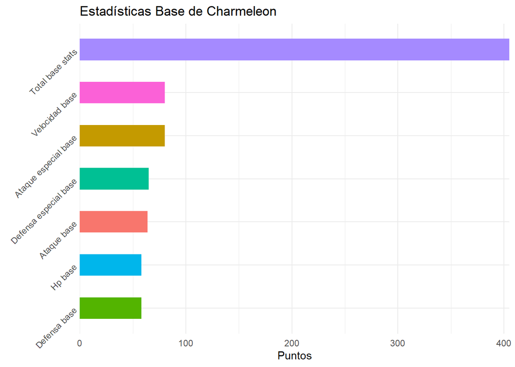

## #006 **Charizard**

### **Foto**

[figure not shown]

foto de charizard

### **Descripcion de la pokedex**

Escupe fuego tan caliente que funde las rocas. Es la causa de muchos incendios forestales.

### **Origen**

- **Nombre en inglés:** *Charizard* es una combinación de “char” *(carbonizar)* y “lizard” *(lagarto)*, con un toque de “blaze” *(llamarada)* o “razor” *(navaja)* para denotar su fuerza.
- **Nombre en japonés:** *Rizādon (リザードン)* es una transcripción de la palabra “lizard” *(lagarto)* con la adición de “don” *(dinosaurio o señor)*, que a menudo se usa para formas finales y poderosas.

### **Caracteristicas**

Caracteristicas de Charizard

| Tipo 1 | Tipo 2 | Proporcion de genero | Color | Forma | Altura (M) | Peso (kg) | Amistad base |
| --- | --- | --- | --- | --- | --- | --- | --- |
| Fire | Flying | 87.5% male / 12.5% female | Red | Winged | 1.7 | 90.5 | 70 |

### **Resistencias y debilidades**

- **Muy débil:** Roca (recibe 4x de daño).
- **Débil:** Agua y Eléctrico (recibe 2x de daño).
- **Resistente:** Lucha, Acero, Fuego, y Volador (recibe 1/2 de daño).
- **Muy resistente:** Bicho y Planta (recibe 1/4 de daño).
- **Inmune:** Tierra (recibe 0x de daño).

### **Etapa evolutiva**

- *Charizard* evoluciona de *Charmeleon* al alcanzar el nivel 36. Es la forma final de esta línea evolutiva.

### **Habilidades**

- **Habilidad Normal:** Mar Llamas (Blaze)

**Efecto:** Aumenta la potencia de los movimientos de tipo Fuego en un 50% cuando el PS del Pokémon está a 1/3 o menos de su capacidad máxima.

- **Habilidad Oculta:** Poder Solar (Solar Power)

**Efecto:** Aumenta el Ataque Especial del Pokémon en un 50% cuando el clima es Día Soleado o Sol Intenso, pero pierde un 1/8 de su PS máximo al final de cada turno. Esta habilidad no está disponible en Pokémon Rojo Fuego y Verde Hoja.

### **Metodo de captura**

En Pokémon Rojo Fuego, Charizard no se encuentra en estado salvaje. La única forma de obtenerlo es evolucionando a Charmeleon.

### **Estadisticas**

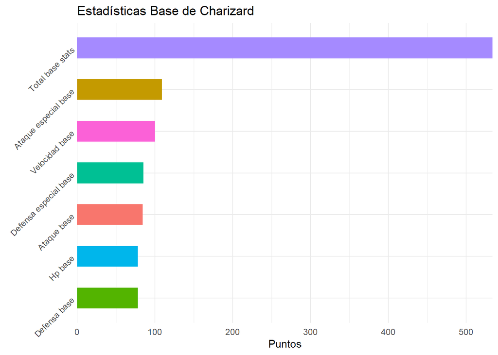

## #007 **Squirtle**

### **Foto**

[figure not shown]

foto de Squirtle

### **descripcion de la pokedex**

Su caparazón no solo le sirve como protección. Su forma redondeada y las hendiduras de su superficie le permiten mejorar su hidrodinamismo en el agua.

### **Origen**

- **Nombre en inglés:** *Squirtle* es una combinación de las palabras “squirt” *(chorro de agua)* y “turtle” *(tortuga)*. Esto hace referencia a su naturaleza de tipo Agua y a su apariencia de tortuga.
- **Nombre en japonés:** *Zenigame (ゼニガメ)* se traduce como “tortuga de dinero”. Proviene de “zeni” *(dinero, en referencia a las monedas de diez yenes por su parecido con el caparazón de la tortuga)* y “kame” *(tortuga)*.

### **Caracteristicas**

Caracteristicas de Squirtle

| Tipo 1 | Tipo 2 | Proporcion de genero | Color | Forma | Altura (M) | Peso (kg) | Amistad base |
| --- | --- | --- | --- | --- | --- | --- | --- |
| Water | NA | 87.5% male / 12.5% female | Blue | Bipedal | 0.5 | 9 | 70 |

### **Resistencias y debilidades**

- **Débil**: Eléctrico y Planta (recibe 2x de daño).
- **Resistente:** Acero, Fuego, Hielo y Agua (recibe 1/2 de daño).
- **Daño normal:** Normal, Lucha, Veneno, Tierra, Volador, Psíquico, Bicho, Roca, Fantasma y Dragón (recibe 1x de daño).

### **Etapa evolutiva**

- *Squirtle* evoluciona a *Wartortle* en el nivel 16.
- *Wartortle* evoluciona a *Blastoise* en el nivel 36.

### **Habilidades**

- **Habilidad Normal:** Torrente (Torrent)

**Efecto:** Aumenta la potencia de los movimientos de tipo Agua en un 50% cuando el PS del Pokémon está a 1/3 o menos de su capacidad máxima.

- **Habilidad Oculta:** Cura Lluvia (Rain Dish)

**Efecto:** El Pokémon recupera un 1/16 de su PS máximo al final de cada turno si está lloviendo. Esta habilidad no está disponible en Pokémon Rojo Fuego y Verde Hoja.

### **Metodo de captura**

Al igual que Bulbasaur y Charmander, Squirtle es uno de los tres Pokémon iniciales que el Profesor Oak ofrece en Pueblo Paleta, por lo que no se puede encontrar en estado salvaje en Pokémon Rojo Fuego.

### **Estadisticas**

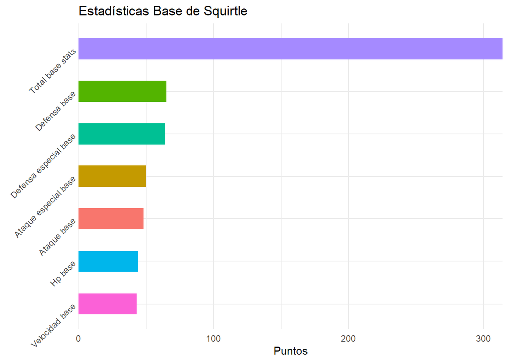

## #008 **Wartortle**

### **Foto**

[figure not shown]

foto de Wartortle

### **Descripcion de la pokedex**

Se lo considera un símbolo de longevidad. Hay ejemplares de más de 10.000 años. La cola de su caparazón se endurece con la edad.

### **Origen**

- **Nombre en inglés:** *Wartortle* es una combinación de “war” *(guerra)*, “tortoise” *(tortuga)*, y “turtle” *(tortuga)*. Esto se refiere a su naturaleza más agresiva y a su caparazón evolucionado.
- **Nombre en japonés:** *Kamēru (カメール)* es una combinación de “kame” *(tortuga)* y “meru”, que se cree que proviene de “mail” *(cota de malla, armadura)* o “whirl” *(remolino)*, aludiendo a su caparazón protector y su movimiento en el agua.

### **Caracteristicas**

Caracteristicas de Wartortle

| Tipo 1 | Tipo 2 | Proporcion de genero | Color | Forma | Altura (M) | Peso (kg) | Amistad base |
| --- | --- | --- | --- | --- | --- | --- | --- |
| Water | NA | 87.5% male / 12.5% female | Blue | Bipedal | 1 | 22.5 | 70 |

### **Resistencias y debilidades**

- **Debil:** Eléctrico y Planta (recibe 2x de daño).
- **Resistente:** Acero, Fuego, Hielo y Agua (recibe 1/2 de daño).
- **Daño normal:** Normal, Lucha, Veneno, Tierra, Volador, Psíquico, Bicho, Roca, Fantasma y Dragón (recibe 1x de daño).

### **Etapa evolutiva**

- *Wartortle* evoluciona de *Squirtle* al alcanzar el nivel 16.
- *Wartortle* evoluciona a *Blastoise* al alcanzar el nivel 36.

### **Habilidades**

- **Habilidad Normal:** Torrente (Torrent)

**Efecto:** Aumenta la potencia de los movimientos de tipo Agua en un 50% cuando el PS del Pokémon está a 1/3 o menos de su capacidad máxima.

- **Habilidad Oculta:** Cura Lluvia (Rain Dish)

**Efecto:** El Pokémon recupera un 1/16 de su PS máximo al final de cada turno si está lloviendo. Esta habilidad no está disponible en Pokémon Rojo Fuego y Verde Hoja.

### **Metodo de captura**

En Pokémon Rojo Fuego, Wartortle no se encuentra en estado salvaje. La única forma de obtenerlo es evolucionando a Squirtle.

### **Estadisticas**

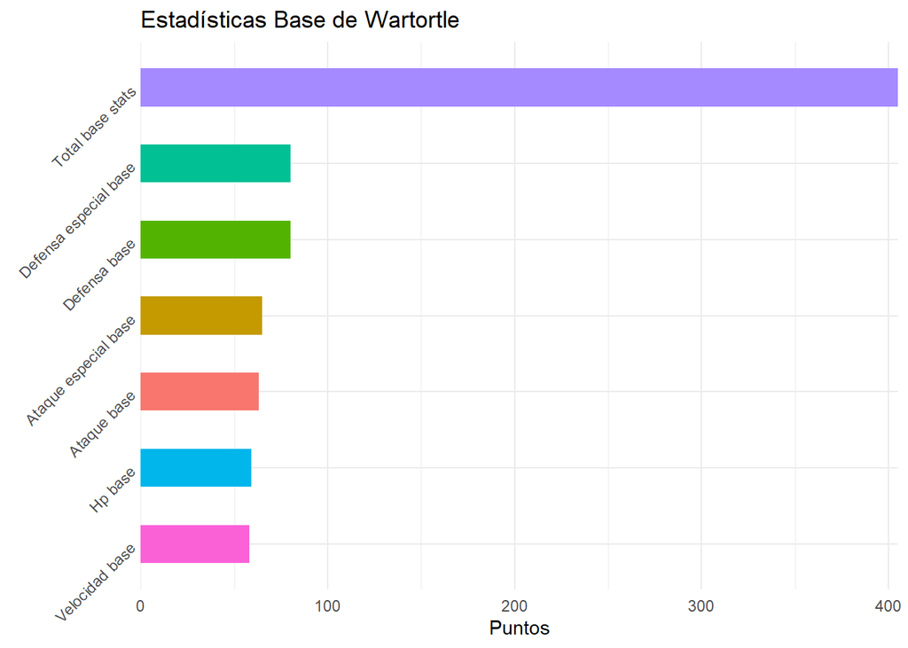